# Data Science II

## How Much of the State Is Covered?

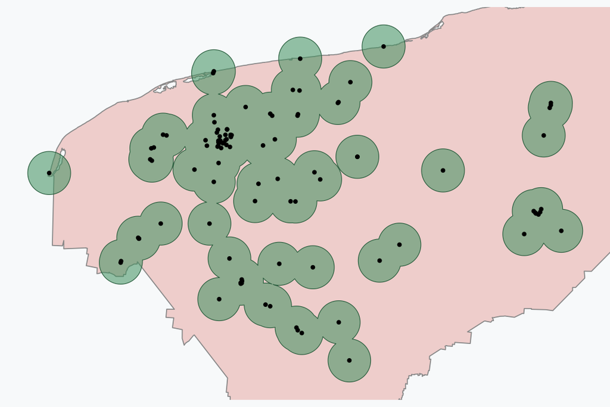

```r
#--- built on earlier slides ---
hospitals <- denue %>%
  filter(substr(as.character(codigo_act), 1, 4) == "6221") %>%
  st_as_sf(coords = c("longitud", "latitud"), crs = 4326)

hosp <- hospitals %>%
  st_transform(6372)

state <- st_union(yuc_p)
buf10 <- st_buffer(hosp, 10000)          # 10 km
buffers_merged <- st_union(buf10)

bb <- st_bbox(st_transform(buf10, 4326))

ggplot() +
  geom_sf(data = state, fill = "#f2d7d5", colour = "grey60", linewidth = 0.3) +
  geom_sf(data = buffers_merged, fill = "#4c9f70", colour = "#2e6b4a", alpha = 0.55) +
  geom_sf(data = hosp, size = 0.7, colour = "black") +
  coord_sf(xlim = bb[c("xmin", "xmax")],
           ylim = bb[c("ymin", "ymax")], crs = 4326) +
  theme_void()
```

`st_union()` melts the overlaps into **one shape**, so ground shared by two hospitals is counted **once**, not twice.

## How Much of the State Is Covered?

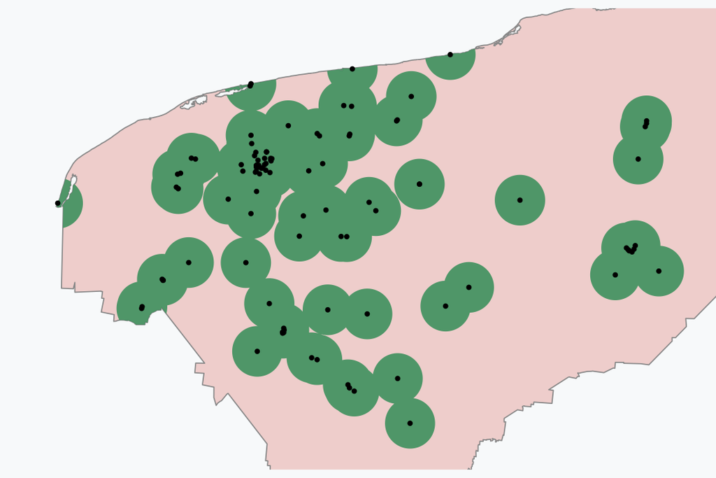

```r
#--- built on earlier slides ---
hospitals <- denue %>%
  filter(substr(as.character(codigo_act), 1, 4) == "6221") %>%
  st_as_sf(coords = c("longitud", "latitud"), crs = 4326)

hosp <- hospitals %>%
  st_transform(6372)

state <- st_union(yuc_p)
buf10 <- st_buffer(hosp, 10000)          # 10 km
buffers_merged <- st_union(buf10)
coverage <- st_intersection(state, buffers_merged)

bb <- st_bbox(st_transform(buf10, 4326))

ggplot() +
  geom_sf(data = state, fill = "#f2d7d5", colour = "grey60", linewidth = 0.3) +
  geom_sf(data = coverage, fill = "#4c9f70", colour = NA, alpha = 0.9) +
  geom_sf(data = hosp, size = 0.7, colour = "black") +
  coord_sf(xlim = bb[c("xmin", "xmax")],
           ylim = bb[c("ymin", "ymax")], crs = 4326) +
  theme_void()
```

`st_intersection(state, covered)` trims it to the land. **Green is within 10 km of a hospital. Pink is not.**

## How Much of the State Is Covered?

Now it is just two areas divided:

```r
#Step1: Areas in km2
area_state <- as.numeric(st_area(state))    / 1e6
area_covered   <- as.numeric(st_area(coverage)) / 1e6

#Step2: The green share of the whole
round(c(state_km2 = area_state, covered_km2 = area_covered,
        percent = 100 * area_covered / area_state), 1)
```

```
  state_km2 covered_km2     percent
    39102.0     11685.9        29.9
```

**Only 29.9% of Yucatán is within 10 km of a hospital** — and that is straight-line distance, so the real figure is worse.

## Other Shapes You Can Derive

**`st_convex_hull`**

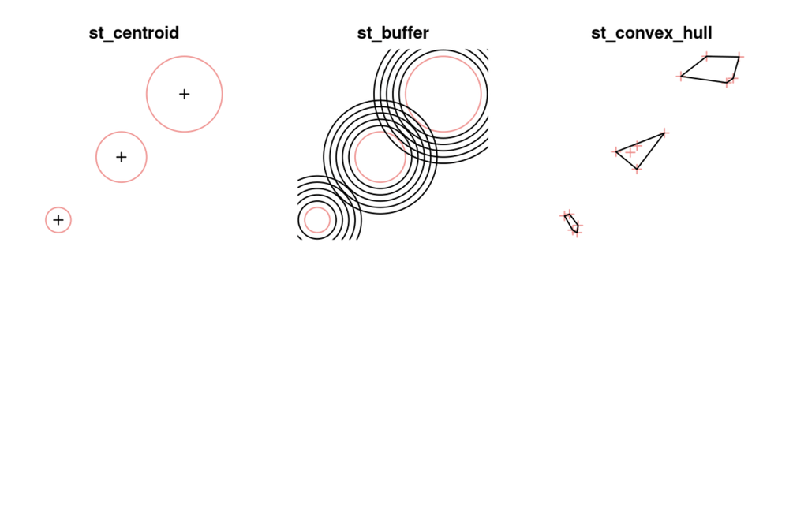

The tightest convex shape containing the points — a crude “service area”.

**`st_sym_difference`**

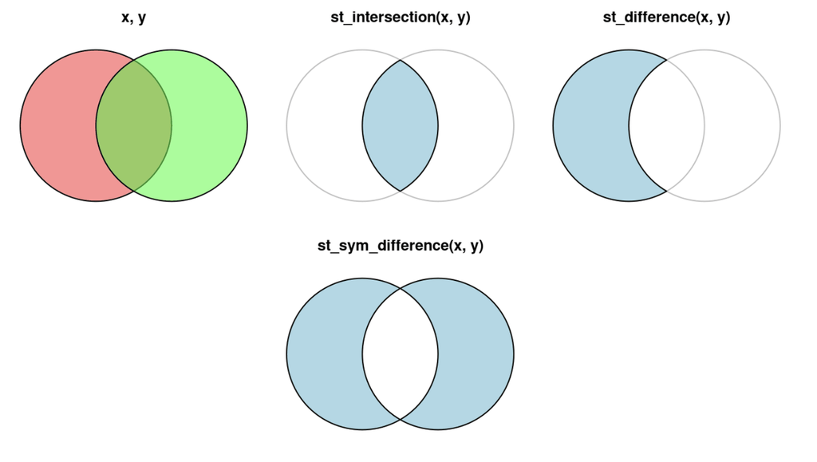

In one or the other, but not both.

## Geometry Casting

```r
#Step1: the state is ONE feature
st_geometry_type(state)
```

```
[1] MULTIPOLYGON
18 Levels: GEOMETRY POINT LINESTRING POLYGON MULTIPOINT ... TRIANGLE
```

One row, one geometry. But a `MULTIPOLYGON` can be made of **many separate pieces**.

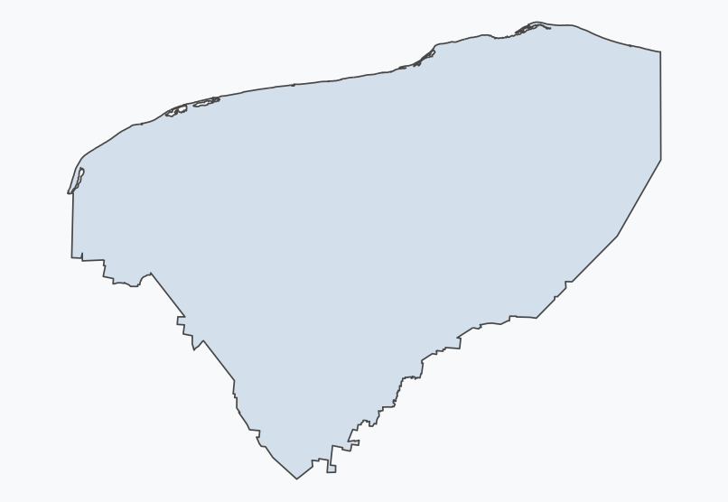

## Geometry Casting

```r
#Step2: break it into its parts
pieces <- st_cast(state, "POLYGON")
length(pieces)
```

```
[1] 6
```

```r
#Step3: how big is each one, in km2?
round(sort(as.numeric(st_area(pieces)) / 1e6,
           decreasing = TRUE), 1)
```

```
[1] 39094.4     4.6     2.3     0.5     0.2     0.0
```

**Six pieces.** The mainland is 39,094 km² — **99.98%** of the state. The other five are islands, the largest 4.6 km².

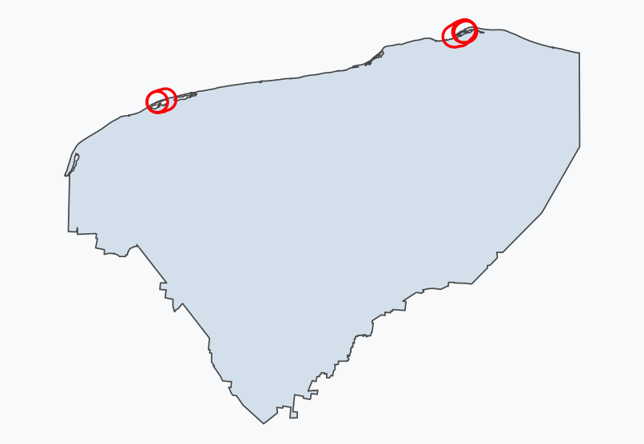

All five sit on the **north coast** — barrier islands, circled.

## Geometry Casting

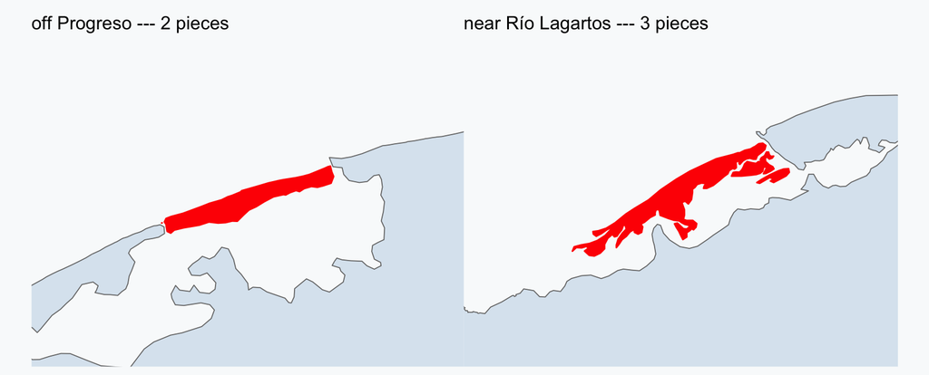

Blue is the mainland, white is water, **red are the five separate pieces**. They are **barrier islands** — cut off from the coast by a lagoon, which is exactly why `sf` stores them as their own polygons.

Together they come to **7.6 km²**. Casting them off changes the state’s area by **0.02%** — but it changes the *number of features* from one to six, and that is what breaks a loop.

## Geometry Casting

```r
#Step4: cast to lines instead -- the boundary on its own
edge <- st_cast(state, "MULTILINESTRING")
st_geometry_type(edge)
```

```
[1] MULTILINESTRING
18 Levels: GEOMETRY POINT LINESTRING POLYGON MULTIPOINT ... TRIANGLE
```

Same coordinates, different **type**. A polygon encloses an area; a line does not — so `st_area(edge)` is now **zero**.

That is what casting is for: keep the shape, change what R thinks it *is*.

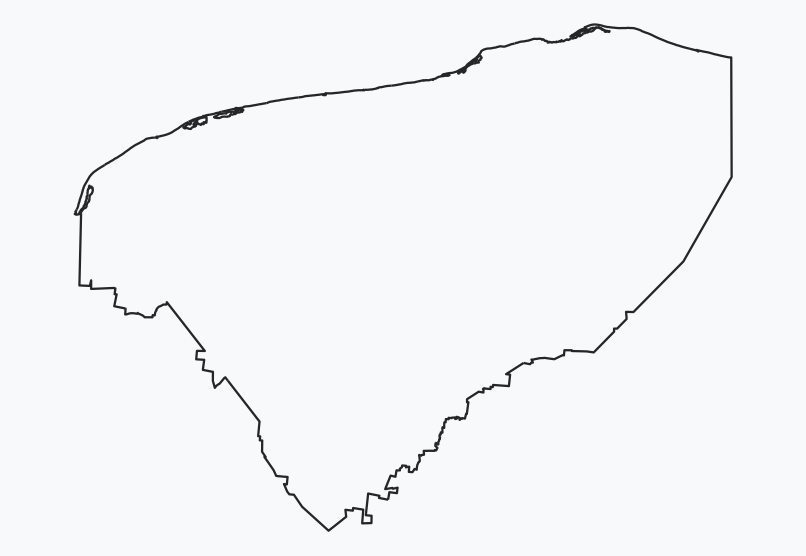

## Geometry Casting: Why Bother?

```r
#How long is Yucatán's border?
st_length(state)
```

```
0 [m]
```

```r
#The same question, after casting
st_length(st_cast(state, "MULTILINESTRING"))
```

```
1219611 [m]
```

**Zero.** A polygon encloses an area; it has no length. `st_length` answers `0` — no error, no warning, just a wrong number you might publish.

Cast it to lines and the border is **1,220 km**.

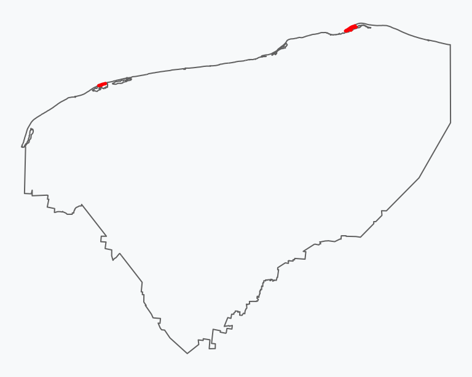

Grey: the mainland edge. Red: the islands.

Those five islands are **0.02% of the area** but **43.8 km of coastline — 3.6% of the total**. Casting them off is an analytical decision, not housekeeping.

# Part D: Putting It Together

## The Whole Analysis

Six operations, in order:

1. `st_as_sf` — coordinates become geometry *(Session 2)*
2. `st_join` — each establishment picks up the municipio it falls in
3. `st_transform` — into metres, EPSG:6372
4. `st_centroid` — one representative point per municipio
5. `st_nearest_feature` + `st_distance` — how far to the nearest hospital
6. `st_buffer` + `st_union` + `st_intersection` — what share of the territory is served

That is a complete accessibility study, in about twenty lines.

## What Have We Learned?

- Three families: **predicates** return `TRUE`/`FALSE`, **measures** return numbers, **constructors** return geometry — and a join is a **predicate plus bookkeeping**
- `st_within` and `st_intersects` differ **only on the boundary**; across 6,460 real points they agreed exactly
- Joining by label and by location disagreed for **8 establishments**, every one on the Mérida metropolitan border, plus **one clinic 34 m outside** the shoreline
- Measurement needs a **projected CRS**: Web Mercator overstates Yucatán by **15.9%**
- **`st_nearest_feature` + `by_element = TRUE`** gives one distance per row instead of a matrix
- **union → intersection → area**: only **29.9%** of the state is within 10 km of a hospital
- `st_length` on a polygon returns **0** — cast to lines first
- Area covered is not **population covered**

**Next session:** rasters — continuous surfaces, and extracting them to your polygons.